# 03 - Stylistic Feature Engineering and Analysis

## 2. Feature Comparison Table

```python
df_features = df_feat.copy()[[c for c in df_feat.columns if c not in ["datetime_posted", "title"]]]
feature_cols = [c for c in df_features.columns if c != 'is_fox']

summary = df_features.groupby('is_fox')[feature_cols].mean().T
summary = summary.rename(columns={0: 'NBC', 1: 'Fox'})

# Pooled std dev and Cohen's d -> from googling about how to compare two groups on multiple features
n_fox, n_nbc = len(df_features[df_features['is_fox'] == 1]), len(df_features[df_features['is_fox'] == 0])
pooled_std = np.sqrt(
    ((n_fox - 1) * df_features[df_features['is_fox'] == 1][feature_cols].std()**2 + (n_nbc - 1) * df_features[df_features['is_fox'] == 0][feature_cols].std()**2)
    / (n_fox + n_nbc - 2)
)

summary['abs_diff'] = (summary['Fox'] - summary['NBC']).abs()
summary['cohens_d'] = (summary['Fox'] - summary['NBC']) / pooled_std
summary['abs_cohens_d'] = summary['cohens_d'].abs()

summary = summary.sort_values('abs_cohens_d', ascending=False)

print('Feature means by source (sorted by |Cohen\'s d|):')
print(summary[['NBC', 'Fox', 'abs_diff', 'cohens_d', 'abs_cohens_d']].round(4).to_string())
```

```
Feature means by source (sorted by |Cohen's d|):
is_fox                   NBC      Fox  abs_diff  cohens_d  abs_cohens_d
n_words              11.8334  13.7625    1.9291    0.7064        0.7064
scare_quote_count     0.1316   0.4495    0.3179    0.5796        0.5796
has_colon             0.1233   0.3270    0.2037    0.4984        0.4984
person_to_ent_ratio   0.1694   0.2869    0.1175    0.3692        0.3692
person_count          0.3959   0.6545    0.2586    0.3629        0.3629
title_case_ratio      0.2655   0.2267    0.0388   -0.2642        0.2642
gpe_count             0.5214   0.3535    0.1679   -0.2459        0.2459
starts_with_number    0.0627   0.0175    0.0452   -0.2354        0.2354
vader_pos             0.1025   0.0867    0.0157   -0.1166        0.1166
allcaps_word_count    0.2521   0.3130    0.0609    0.1165        0.1165
vader_compound       -0.0497  -0.0992    0.0495   -0.1086        0.1086
org_count             0.5136   0.5825    0.0689    0.0981        0.0981
vader_neg             0.1215   0.1349    0.0134    0.0878        0.0878
has_question          0.0183   0.0085    0.0098   -0.0863        0.0863
ellipsis_count        0.0000   0.0020    0.0020    0.0617        0.0617
has_allegedly         0.0150   0.0235    0.0085    0.0616        0.0616
has_sources           0.0011   0.0040    0.0029    0.0564        0.0564
exclamation_count     0.0011   0.0040    0.0029    0.0564        0.0564
org_to_ent_ratio      0.2309   0.2490    0.0181    0.0563        0.0563
has_report            0.0161   0.0220    0.0059    0.0430        0.0430
total_ents            2.1816   2.2225    0.0409    0.0345        0.0345
norp_count            0.2032   0.1895    0.0137   -0.0307        0.0307
type_token_ratio      0.9891   0.9898    0.0007    0.0256        0.0256
has_says              0.1055   0.1000    0.0055   -0.0181        0.0181
vader_neu             0.7760   0.7784    0.0024    0.0139        0.0139
```

```python
print('\nTop 10 features by Cohen\'s d:')
print(summary.head(10)[['NBC', 'Fox', 'cohens_d', 'abs_cohens_d']].round(4).to_string())
```

```
Top 10 features by Cohen's d:
is_fox                   NBC      Fox  cohens_d  abs_cohens_d
n_words              11.8334  13.7625    0.7064        0.7064
scare_quote_count     0.1316   0.4495    0.5796        0.5796
has_colon             0.1233   0.3270    0.4984        0.4984
person_to_ent_ratio   0.1694   0.2869    0.3692        0.3692
person_count          0.3959   0.6545    0.3629        0.3629
title_case_ratio      0.2655   0.2267   -0.2642        0.2642
gpe_count             0.5214   0.3535   -0.2459        0.2459
starts_with_number    0.0627   0.0175   -0.2354        0.2354
vader_pos             0.1025   0.0867   -0.1166        0.1166
allcaps_word_count    0.2521   0.3130    0.1165        0.1165
```

## 3. Distribution Plots for Top 12 Features

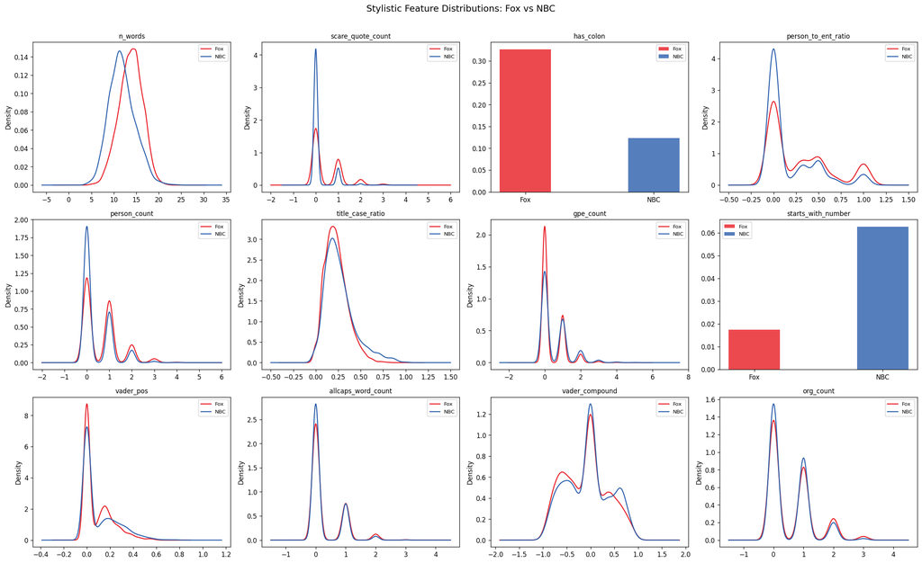

```python
top_features = summary.head(12).index.tolist()

fig, axes = plt.subplots(3, 4, figsize=(20, 12))
axes = axes.flatten()

for i, feat in enumerate(top_features):

    ax = axes[i]

    for source, val, color in [('Fox', 1, FOX_COLOR), ('NBC', 0, NBC_COLOR)]:
        subset = df_features[df_features['is_fox'] == val][feat]

        if subset.nunique() <= 2:
            ax.bar(source, subset.mean(), color=color, alpha=0.8, width=0.4, label=source)

        else:
            try:
                subset.plot.kde(ax=ax, label=source, color=color)
            except Exception:
                ax.hist(subset, bins=20, alpha=0.5, label=source, color=color)

    ax.set_title(feat, fontsize=10)
    ax.legend(fontsize=8)

plt.suptitle('Stylistic Feature Distributions: Fox vs NBC', fontsize=14, y=1.01)
plt.tight_layout()

os.makedirs("../figures", exist_ok = True)
plt.savefig('../figures/stylistic_distributions.png', dpi=150, bbox_inches='tight')

plt.show()
```

We select features based on three criteria:

1. **Large absolute Cohen's D difference** (top of the ranking above)
2. **Separable distributions** (KDE or bar plots show clear separation, not heavy overlap)
3. **Interpretability** (the feature has a plausible stylistic explanation)

Based on the criteria we chose the features with a Cohen's D above 0.35. We observe a sharp drop off in Cohen's D below 0.35 and many of the remaining features have inflated Cohen's D values due to it's low variance rather than an actual difference in mean values. The 5 features we chose also were clearly differentiated via their density/bar plots as well, further indicating that they present in a meaningfully different way in Fox vs NBC headlines.

### Selected:

[output not shown]

### Excluded (distributions overlap too heavily to be useful):

`has_says`, `has_report`, `vader_neu`, `type_token_ratio`, `ellipsis_count`, `exclamation_count`, `has_question`, `has_allegedly`, `has_sources`, `org_count`, `norp_count`, `vader_pos`, `vader_neg`, `total_ents`, `org_to_ent_ratio`, `gpe_count`, `starts_with_number`, `title_case_ratio`

```python
# Define discriminative features
FEATURES = ["n_words", "scare_quote_count", "has_colon", "person_to_ent_ratio", "person_count"]

print('Selected feature summary:')
print(summary.loc[[f for f in FEATURES if f in summary.index]].round(4).to_string())
```

```
Selected feature summary:
is_fox                   NBC      Fox  abs_diff  cohens_d  abs_cohens_d
n_words              11.8334  13.7625    1.9291    0.7064        0.7064
scare_quote_count     0.1316   0.4495    0.3179    0.5796        0.5796
has_colon             0.1233   0.3270    0.2037    0.4984        0.4984
person_to_ent_ratio   0.1694   0.2869    0.1175    0.3692        0.3692
person_count          0.3959   0.6545    0.2586    0.3629        0.3629
```

## 5. Save Style Features for Modeling

```python
# Use df_feat from section 1
print("Extracting selected style features...")
final_features_df = df_feat.copy()
final_features_df = final_features_df[["datetime_posted", "title"] + FEATURES + ["is_fox"]]

# Write to processed data dir for easy access in next notebook
os.makedirs("../data/processed", exist_ok = True)

print(f"\nSaving final features to ../data/processed/style_features.csv with shape {final_features_df.shape}...")
final_features_df.to_csv("../data/processed/style_features.csv", index = False)
print(f"\nSaved.\n")

print("\nFinal saved feature descriptive statistics:")
print(final_features_df.describe().to_string())
```

```
Extracting selected style features...

Saving final features to ../data/processed/style_features.csv with shape (3801, 8)...

Saved.


Final saved feature descriptive statistics:
                  datetime_posted      n_words  scare_quote_count    has_colon  person_to_ent_ratio  person_count       is_fox
count                        3711  3801.000000        3801.000000  3801.000000          3801.000000   3801.000000  3801.000000
mean   2023-12-27 08:21:31.720034    12.848461           0.298869     0.230466             0.231264      0.531965     0.526177
min           2020-01-06 17:10:00     4.000000           0.000000     0.000000             0.000000      0.000000     0.000000
25%    2023-08-08 22:57:30.375500    11.000000           0.000000     0.000000             0.000000      0.000000     0.000000
50%           2024-06-05 09:55:28    13.000000           0.000000     0.000000             0.000000      0.000000     1.000000
75%    2024-09-18 01:31:38.500000    15.000000           0.000000     0.000000             0.500000      1.000000     1.000000
max    2026-04-07 20:29:18.893000    24.000000           4.000000     1.000000             1.000000      4.000000     1.000000
std                           NaN     2.895583           0.570892     0.421186             0.323561      0.724090     0.499380
```

```python
# Save matching numpy arrays of embeddings for next notebook
from sentence_transformers import SentenceTransformer

feature_df = pd.read_csv("../data/processed/style_features.csv", index_col=0)

embedder = SentenceTransformer("all-MiniLM-L6-v2")
embeddings = embedder.encode(feature_df["title"].fillna("").tolist(), show_progress_bar=True)

np.save("../data/processed/minilm_embeddings.npy", embeddings)
print(f"Saved embeddings shape: {embeddings.shape}")
```

```
Saved embeddings shape: (3801, 384)
```